# Case2

Murilo Mendel Costa

08/07/2020

### Brazilian imports/exports;

#### This document contain a report study about Brazilian monthly imports and exports, mantained by the government from 1997 to 2019.

#### The data set is composed by 117965 rows, 8 columns and has no missing value. The 8 columns are describe as:

#### 1. date: date variable type from 1997-01-01 to 2019-12-01

#### 2. product (categorical char variable): represents the product imported/exported: [corn, soybean_meal, soybean_oil, soybeans, sugar, wheat]

#### 3. state (Categorical char feature: Brazilian states abreviation from/to where the export/import are related: all 26 brazilian states initials.

#### 4. country (Categorical char feature): Countries from/to where the export/import are to/from: 212 different countries.

#### 5. type (Categorical char feature): type of commercial operation: [Export, Import]

#### 6. route (categorical char feature): means the transportation way for the commercial operation: [Air, Ground, River, Sea, Other]

#### 7. tons (numerical float feature): total weight quantity exported/imported in tons.

#### 8. usd (numerical integer value): price over the operation in USD.

### Evolution of total monthly exports from Brazil of Soybeans, Soybean Oil and Soybean Meal

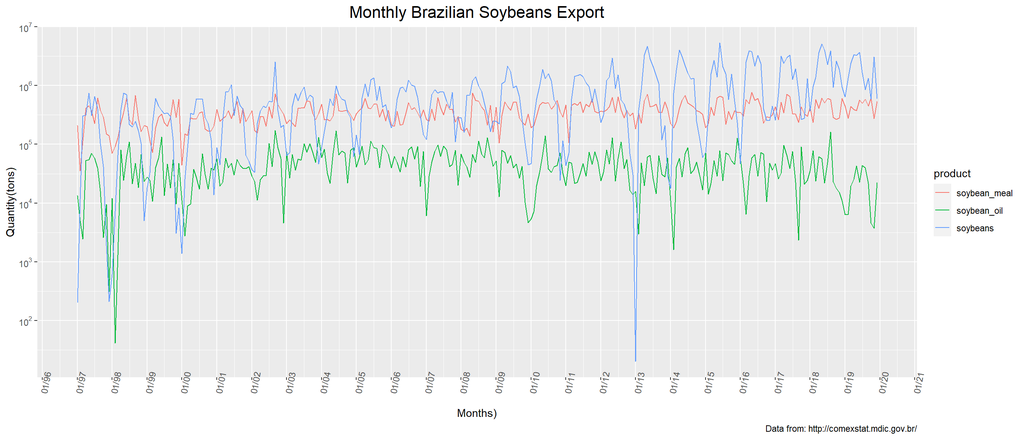

#### It’s possible to recognize some general patterns graphically:

#### - The average monthly export of Soybeans is the biggest, however it has the biggest variance too.

#### - The average monthly export of Soybean Meal is the second biggest and has a lower variance than Soybeans.

#### - The average monthly export of Soybean Oil is the smallest of these three products.

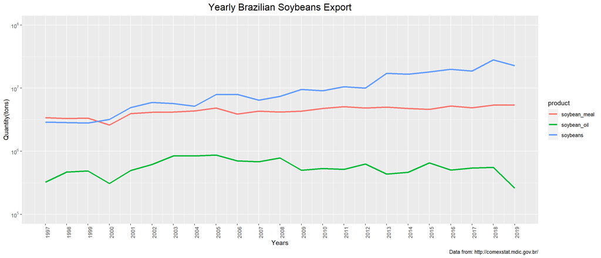

#### From the Yearly report:

#### - Soybeans are the main exported product between the three observed, by soybean meal and soybean Oil.

#### - Soybeans and Soybean meal export quantity increased over time.

## Top 3 most important products exported in the last 5 years

```
##        product total_tons    total_USD yearly_profit
## 1     soybeans  326331464 123325529857   24665105971
## 2        sugar  120033649  40938486021    8187697204
## 3 soybean_meal   76647488  28407723437    5681544687
## 4         corn  144599338  24447720910    4889544182
## 5  soybean_oil    6711428   4795946873     959189375
## 6        wheat    3885836    726945386     145389077
```

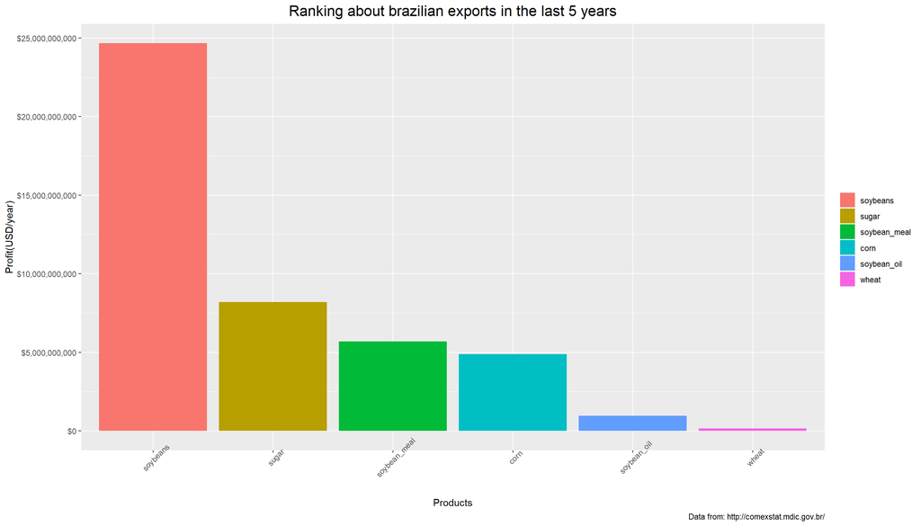

#### The 3 most important products exported by Brazil in the last five years was:

#### 1. Soybeans: 24,665,105,971 [$/year].

#### 2. Sugar: 8,187,697,204 [$/year]

#### 3. Soybean Meal: 5,681,544,687 [$/year]

### Routes Study:

#### The main route through corns are exported from Brazil are from Sea, due to the following table:

```
##    route   total_tons
## 1    Sea 138380994.31
## 2  River   5869626.57
## 3  Other    266055.15
## 4 Ground     72509.53
## 5    Air     10152.61
```

#### The next analysis shows that there is not a difference between products and routes for exportats in Brazil, since the main export route are by Sea for every product.

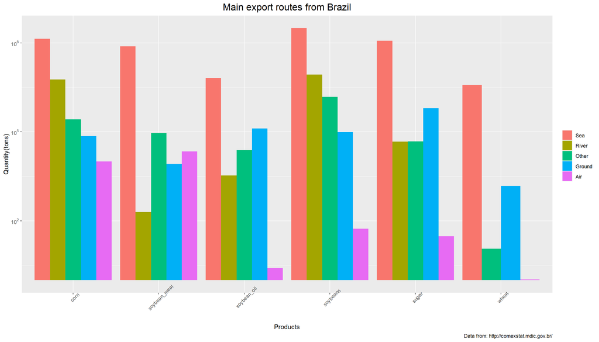

### Trade Partners:

#### The following analysis shows the top 10 most important trade partners for Brazil considering corn and sugar commercial trades over the last 3 years.

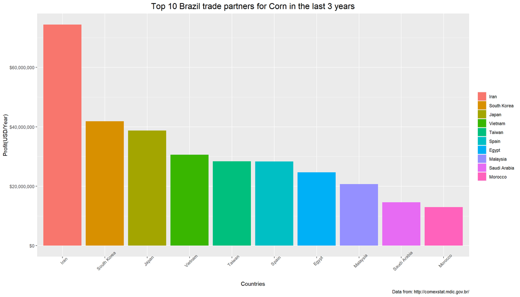

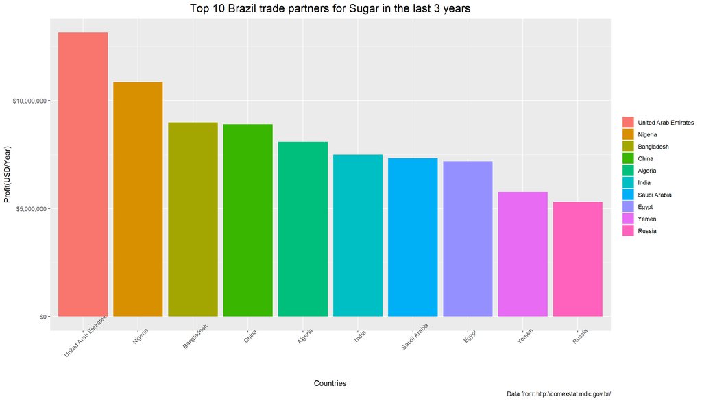

#### From the graph, United Arab Emirates and Nigeria was the main brazilian trade partners for sugar for the last 3 years, followed by Bangladesh and China.

### Main states in exports for each product

#### The following analysis shows the main brazilian states in exports for each product from 1997 to 2019.

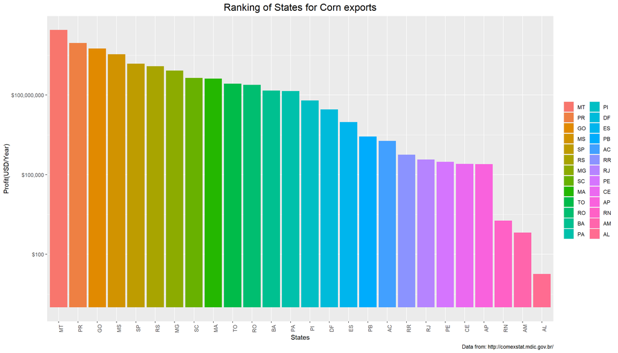

#### The main states for corn exports are: MT, PR, GO, MS and SP.

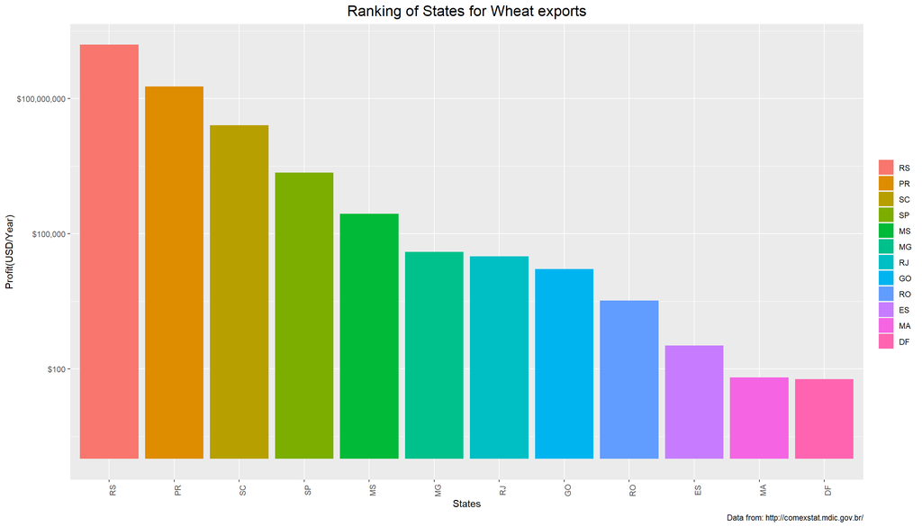

#### The main states for Wheat exports are: RS, PR, SC, SP and MS.

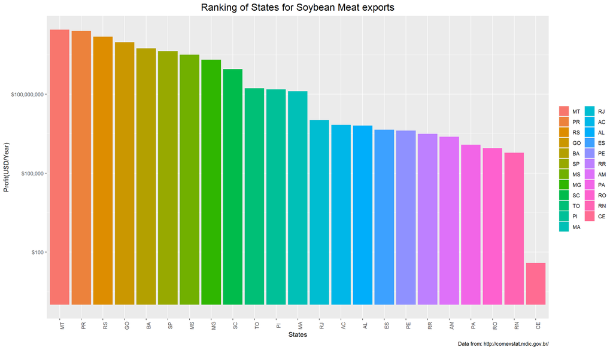

#### The main states for Soybean Meat exports are: MT, PR, RS, GO and BA.

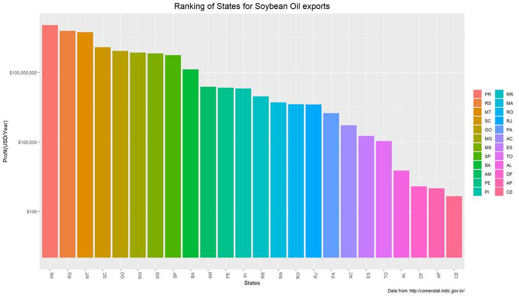

#### The main states for Soybean Oil exports are: PR, RS, MT, SC and GO.

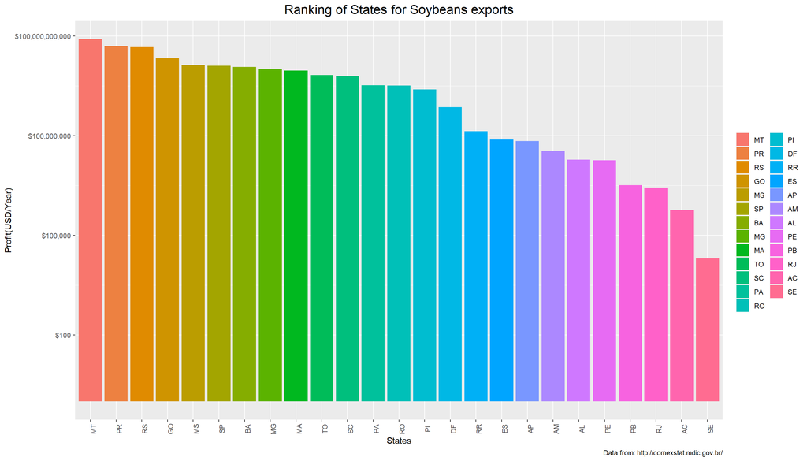

#### The main states for Soybeans exports are: MT, PR, RS, GO and MS.

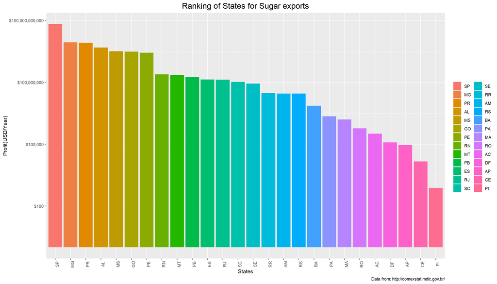

#### The main states for Sugar exports are: SP, MG, PR, AL and MS.

### Export prediction

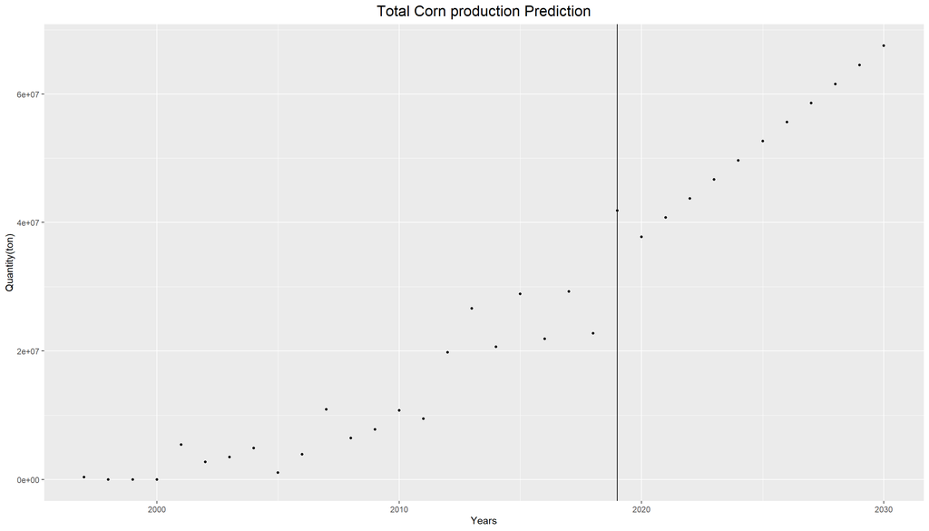

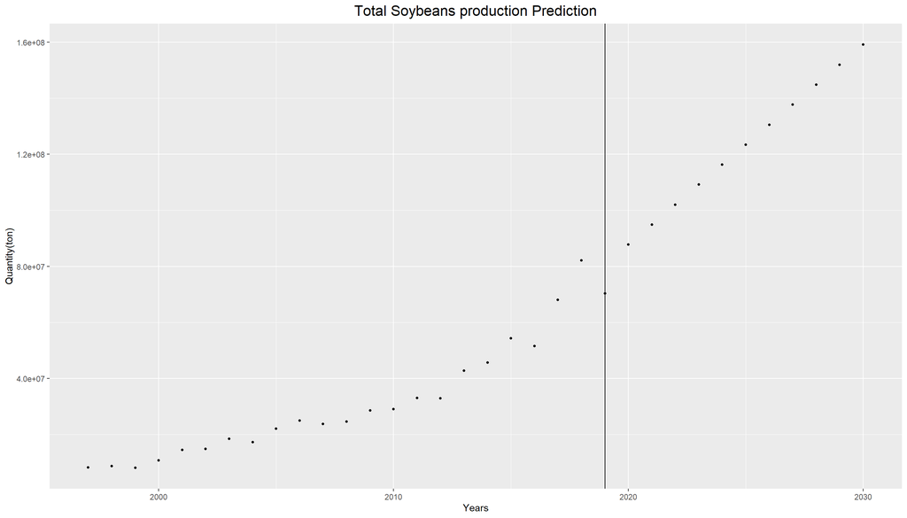

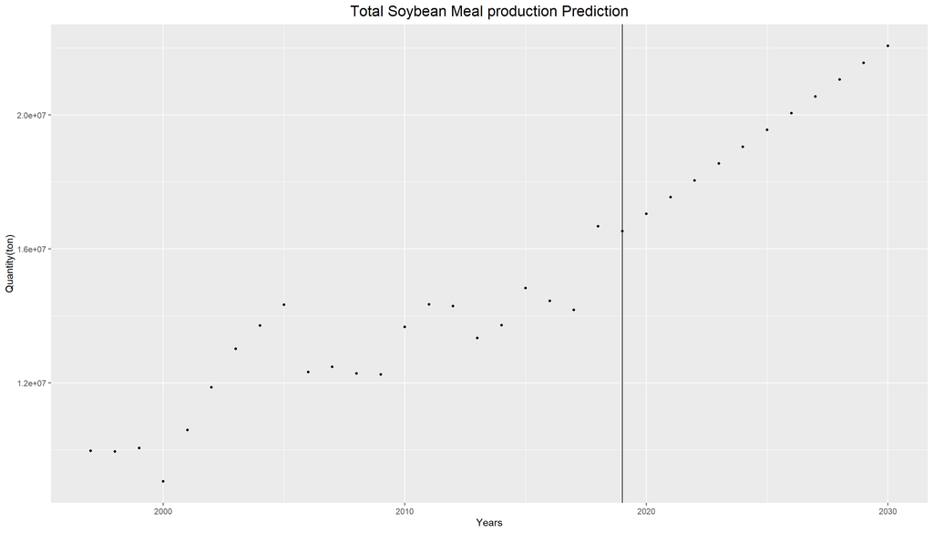